# Lab 5

Kordell Schrock

11/7/2020

```r
acc <- read.csv("https://raw.githubusercontent.com/xdaiISU/ds202materials/master/hwlabs/fars2017/accident.csv", stringsAsFactors = FALSE)
#import accident data
person <- read.csv("https://raw.githubusercontent.com/xdaiISU/ds202materials/master/hwlabs/fars2017/person.csv", stringsAsFactors = FALSE)
#import person data
```

1. Are there some days of the week where more accidents happen than the others (see FARS manual, use variable DAY_WEEK)?

## By looking at the Bar chart showing the days of the week. We see an increase in accidents for Friday, Saturday, and Sunday.

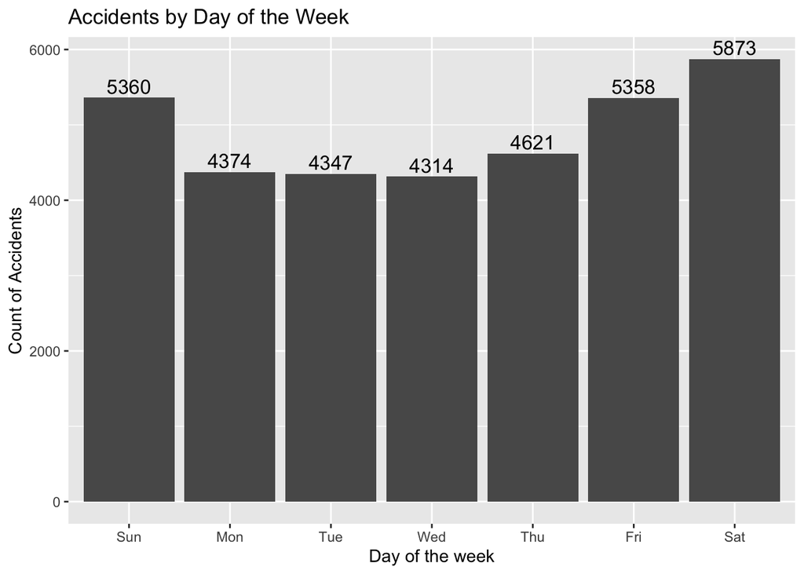

```r
DayOfTheWeek <- acc %>%
  filter(DAY_WEEK != "NA") %>%
  mutate(DayOfTheWeek  = wday(DAY_WEEK, label = TRUE))%>% #change to day of the week instead of number
  select(DAY_WEEK, DayOfTheWeek) %>% #select columns
  count(DayOfTheWeek, na.rm=TRUE) %>% # count the Day Of The Week
  rename('count' = n) #rename n as count

ggplot(DayOfTheWeek, aes(DayOfTheWeek, count)) +
  geom_bar(stat = "identity") +
  ggtitle("Accidents by Day of the Week") + labs(x="Day of the week", y="Count of Accidents") +
  geom_text(aes(x=DayOfTheWeek,y=count,label=count),vjust=-.3, size =4.4)
```

2. Create a data frame containing the persons who are fatally hurt in the accidents (look up variable INJ_SEV).

## fatal is the dataset that contains the most fatal injuries.

```r
fatal <- person %>%
  filter(INJ_SEV == 4) #look up variable INJ_SEV find the critical ones with the value of max number which is 4
head(fatal)
```

```
##   STATE ST_CASE VE_FORMS VEH_NO PER_NO STR_VEH COUNTY DAY MONTH HOUR MINUTE
## 1     1   10001        1      1      1       0     73  19     2   23     35
## 2     1   10002        1      1      1       0     89  14     2   14     59
## 3     1   10003        3      2      1       0    101  31     1   20     31
## 4     1   10004        1      1      1       0     73   1     1   16     55
## 5     1   10005        1      1      1       0     13   1     1   20      0
## 6     1   10006        2      1      1       0     49   6     1   18     40
##   RUR_URB FUNC_SYS HARM_EV MAN_COLL SCH_BUS MAKE MAK_MOD BODY_TYP MOD_YEAR
## 1       2        1      38        0       0   20   20421       15     2004
## 2       2        1       1        0       0   37   37402       14     2005
## 3       2        1      12        1       0    2    2404       14     2003
## 4       2        4      30        0       0   30   30046        4     2014
## 5       1        1      35        0       0   12   12471       34     2010
## 6       1        1      34        0       0   49   49032        4     1997
##   TOW_VEH SPEC_USE EMER_USE ROLLOVER IMPACT1 FIRE_EXP AGE SEX PER_TYP INJ_SEV
```

[output cut: 41 more lines]

3.Create a data frame containing the most dangerous vehicle make in each state. The number of persons fatally hit in the vehicle make is used to assess the (non-)safety of a make. Make sure to handle the missing values appropriately (look up variable MAKE).

## dangerousCarsPerState dataset contains the most dangerous vehicle make in each state

```r
dangerousCarsPerState <- fatal %>%
  select(STATE, INJ_SEV, MAKE) %>% #select the columns we need State, Vehicles, Injuries.
  filter(MAKE != "NA") %>% #filter our missing values
  group_by(STATE, MAKE) %>% #group the states and Vehicles
  count(MAKE) %>% #count the accidents by Vehicle's
  group_by(STATE) %>% #group by the states
  top_n(n=1, n) %>%
  mutate(Vehicle = str_replace_all(MAKE, c("12" = "Ford", "20" = "Chevrolet","37" = "Honda" , "49" = "Toyota"))) %>%
  #from the manual, change the Attribute Codes to actaul Vehicle Make
  rename('Accident Count' = n) %>% #rename n to Accident Count
  rename("State Code"= STATE) #rename STATE to State Code

print(dangerousCarsPerState )
```

```
## # A tibble: 54 x 4
## # Groups:   State Code [51]
##    `State Code`  MAKE `Accident Count` Vehicle
##           <int> <int>            <int> <chr>
##  1            1    12              138 Ford
##  2            2    12                9 Ford
##  3            4    20               88 Chevrolet
##  4            5    20               88 Chevrolet
##  5            6    49              351 Toyota
##  6            8    12               63 Ford
##  7            8    37               63 Honda
##  8            9    37               28 Honda
##  9           10    37               12 Honda
## 10           11    37                5 Honda
## # … with 44 more rows
```

4. Create a map, and label each state with the most dangerous vehicle. Discuss the definition of the most dangerous vehicle, and what you find from the map. (Hint: Read the description for the STATE and COUNTY columns in the FARS manual. The state & county codes are Geographic Locator Codes (GLCs) from the General Services Administration’s (GSA) publication. Use readxl::read_xlsx to read in the GLCs.)

## Looking at the map we see that chevy’s are the vehicle with the most accidents per state.

```r
GLCUS <- readxl::read_excel(path = "./GLC_United_States.xlsx", sheet = 1)
#import the excel data
stateLatLong <- readr::read_csv("./statelatlong.csv")
```

```r
#import state Lat Long CSV

stateCode <- GLCUS %>%
  distinct(`State Code`, `State Name`)
#get all the unique data with State Code and State Name

stateCode$"State Code" <- as.numeric(as.character(stateCode$"State Code"))
#convert the State Code Column from character to int

Vehicle <- stateCode %>%
  inner_join(dangerousCarsPerState, by="State Code")
#inner join the stateCode with the dangerousCarsPerState by State Code Column


drop <- c("State")
stateLatLong = stateLatLong[,!(names(stateLatLong) %in% drop)]
#dropping the State Column

stateLatLong <- stateLatLong %>%
    rename("State Name" = City)
#rename the City Column to State Name

states <- map_data("state")  %>%
          rename("State Name" = region)
#rename the region column to State Name

stateLatLong$"State Name" <- tolower(stateLatLong$"State Name")
#change the State Name column values to lower case
Vehicle$"State Name" <- tolower(Vehicle$"State Name")
#change the State Name column values to lower case

states_coordinates_vehicles_accidents <- Vehicle %>%
  left_join(stateLatLong, by = "State Name" )
#left join by State Name since the values will match accordingly.

states_coordinates_vehicles_accidents <- states_coordinates_vehicles_accidents[!duplicated(states_coordinates_vehicles_accidents), ]
#remove duplicates

head(states_coordinates_vehicles_accidents)
```

```
## # A tibble: 6 x 7
##   `State Name` `State Code`  MAKE `Accident Count` Vehicle   Latitude Longitude
##   <chr>               <dbl> <int>            <int> <chr>        <dbl>     <dbl>
## 1 alabama                 1    12              138 Ford          32.6     -86.7
## 2 alaska                  2    12                9 Ford          61.3    -159.
## 3 arizona                 4    20               88 Chevrolet     34.2    -112.
## 4 arkansas                5    20               88 Chevrolet     34.8     -92.1
## 5 california              6    49              351 Toyota        37.3    -119.
## 6 colorado                8    12               63 Ford          39.0    -106.
```

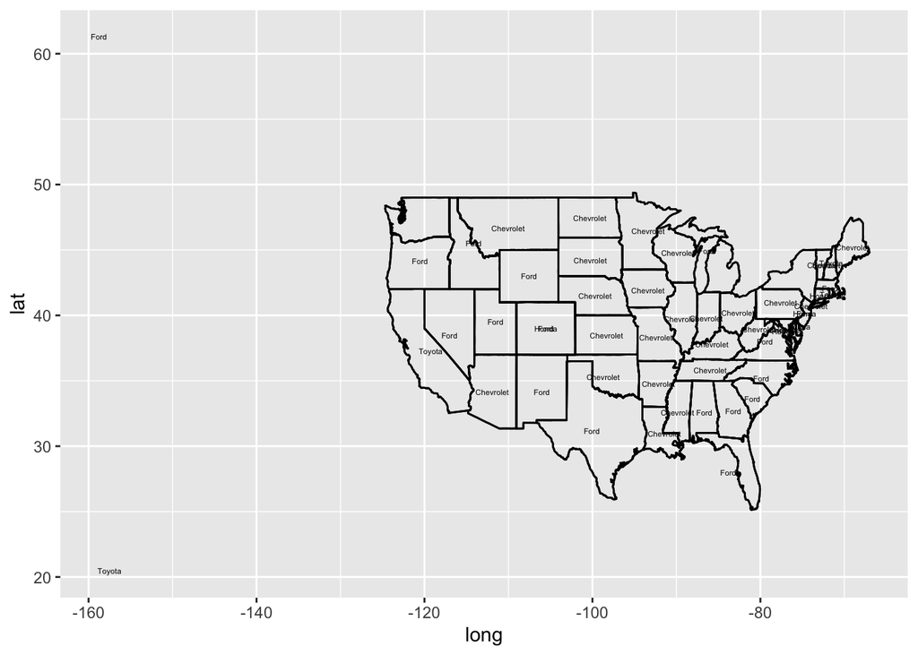

```r
#print head

ggplot(states, aes(x=long, y=lat),) + geom_path(aes(group=group)) + geom_polygon(aes(group=group), colour='black', fill=NA) + geom_text(data=states_coordinates_vehicles_accidents, aes(x=Longitude, y=Latitude, label = Vehicle), size=1.5)
```

5.Join the accident and person table (work out which variable(s) to use)

## Person_Accident is the dataset that joined the person and accident datasets.

```r
Person_Accident <- person %>%
  left_join(acc, by="ST_CASE") %>%
  #left join by ST_CASE
  rename("Hour" = HOUR.y) %>%
  #rename Hour
  rename("Day" = DAY.y) %>%
  #rename Day
  rename("Month"= MONTH.y) %>%
  #rename Month
  rename("Minute" = MINUTE.y)
  #rename Minute
head(Person_Accident)
```

```
##   STATE.x ST_CASE VE_FORMS.x VEH_NO PER_NO STR_VEH COUNTY.x DAY.x MONTH.x
## 1       1   10001          1      1      1       0       73    19       2
## 2       1   10002          1      1      1       0       89    14       2
## 3       1   10003          3      1      1       0      101    31       1
## 4       1   10003          3      2      1       0      101    31       1
## 5       1   10003          3      3      1       0      101    31       1
## 6       1   10004          1      1      1       0       73     1       1
##   HOUR.x MINUTE.x RUR_URB.x FUNC_SYS.x HARM_EV.x MAN_COLL.x SCH_BUS.x MAKE
## 1     23       35         2          1        38          0         0   20
## 2     14       59         2          1         1          0         0   37
## 3     20       31         2          1        12          1         0   82
## 4     20       31         2          1        12          1         0    2
## 5     20       31         2          1        12          1         0   84
## 6     16       55         2          4        30          0         0   30
##   MAK_MOD BODY_TYP MOD_YEAR TOW_VEH SPEC_USE EMER_USE ROLLOVER IMPACT1 FIRE_EXP
```

[output cut: 76 more lines]

```r
#show head of dataset
```

6.Tally the number of accidents by day of the week (DAY_WEEK), hour of the day (HOUR) and gender (SEX). Visualize the results.

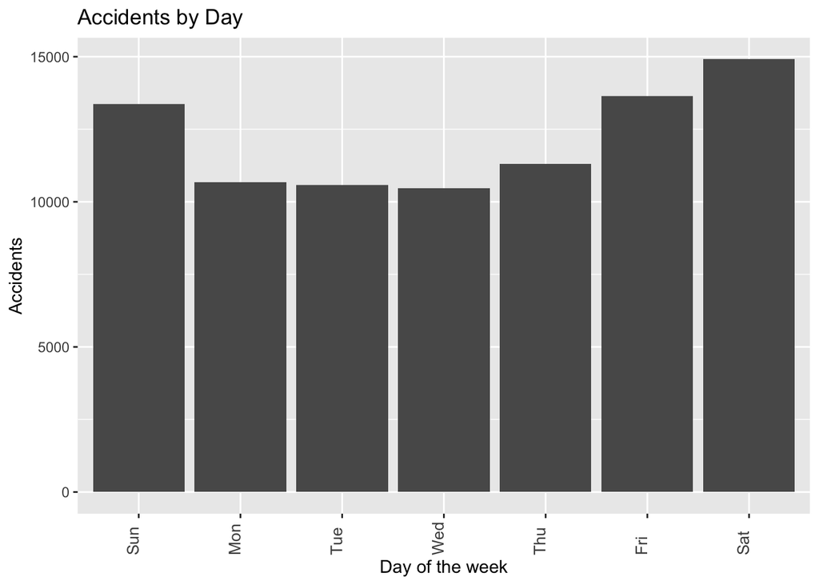

```r
Person_Accident_DayOfWeek <- Person_Accident %>%
  mutate(DayOfTheWeek  = wday(DAY_WEEK, label = TRUE))%>%
  #Change the Day_week number to actual written Day of Week instead of number
  select(DAY_WEEK, DayOfTheWeek, Hour, SEX) %>%
  #Select the columns
  group_by(DayOfTheWeek, Hour, SEX)%>%
  #Group the columns
  tally() %>%
  #tally up the groups
  rename("count" = n)
  #rename n as count

ggplot(Person_Accident_DayOfWeek, aes(DayOfTheWeek, count)) +
  geom_bar(stat = "identity") + labs(x="Day of the week", y="Accidents") +
  ggtitle("Accidents by Day") +
  theme(axis.text.x = element_text(angle=90, hjust=0, size=10, vjust = 0))
```

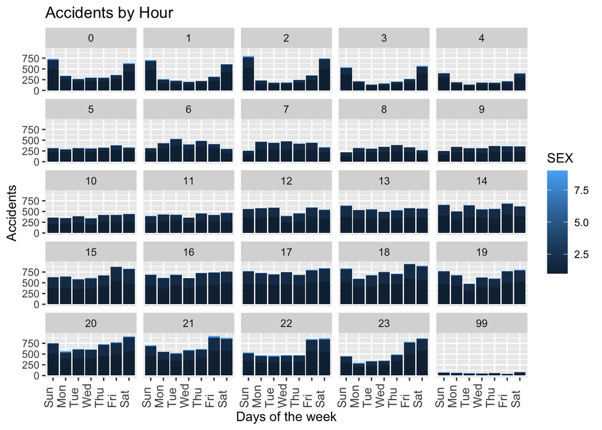

```r
ggplot(Person_Accident_DayOfWeek, aes(DayOfTheWeek, count, fill=SEX)) +
  geom_bar(stat = "identity") + labs(x="Days of the week", y="Accidents") +
  ggtitle("Accidents by Hour") +
  theme(axis.text.x = element_text(angle=90, hjust=0, size=10, vjust = 0)) +
  facet_wrap(~Hour)
```

7.Now plot a choropleth map of the number of deaths on a county level.

## we see some coutnies in the border have texas and a county in minnesota have lower deaths per county than rest of the counties. This is probably areas of lower populated areas.

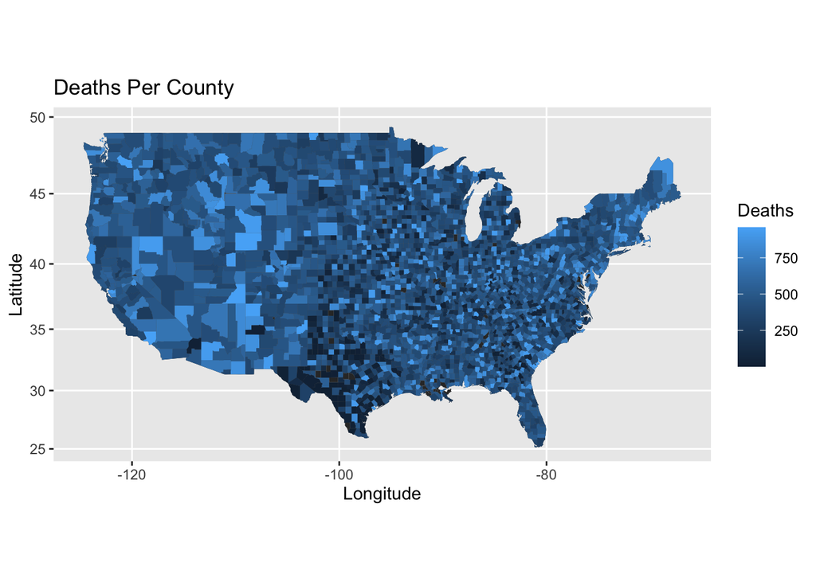

```r
counties <- map_data("county") %>%
#get the counties from the map_data lib
  rename("County Name" = subregion)
  #rename subregion to County Name

countyCodes <- GLCUS %>%
  select(c('County Name', 'County Code'))
#get the county names and county codes within the dataset

countyCodes$"County Code" <- as.numeric(as.character(countyCodes$"County Code"))
#change County Code from char to int

deathsByCounty = acc %>%
  group_by(COUNTY) %>%
  #group by County
  summarise('Deaths' = sum(FATALS), .groups = 'drop') %>%
  #summarise the sum of fatal deaths by group/county
  rename('County Code' = COUNTY)
  #rename county to County Code

countyDeaths <- deathsByCounty %>%
  inner_join(countyCodes, by = 'County Code') %>%
  #inner join deathsByCounty and countyCodes by County Code
  mutate(`County Name` = tolower(`County Name`)) %>%
  #lowercase the County Name column
  distinct() %>%
  #get only distinct/unique values
  inner_join(counties, by ='County Name')
  #inner join counties by County Code

ggplot(counties, aes(x = long, y = lat)) + geom_polygon(aes(group = group)) + geom_polygon(data = countyDeaths, aes(x = long, y = lat, group = group, fill = `Deaths`))+ coord_map() + ggtitle('Deaths Per County') + labs(x="Longitude", y="Latitude")
```

8.Is summer or winter more dangerous? Does this depend on states? Explore and explain.

## Looking at the summer months and the winter months. We see that accidents happen less in the winter months. This could be that people drive more cautious in winter months due to winter storms or because its the holiday season.

```r
summer <- acc %>%
  filter(MONTH == 5 | MONTH == 6 | MONTH == 7 | MONTH == 8)
  #filter the summer months

winter <- acc %>%
  filter(MONTH == 1 | MONTH == 2 | MONTH == 11 | MONTH == 12)
  #filter the winter months

summer %>%
  group_by(STATE)%>%
  #group by state
  summarise("Summer Total" = n(), .groups = 'drop')%>%
  #get the total accidents by state
  top_n(10, "Summer Total")
```

```
## # A tibble: 51 x 2
##    STATE `Summer Total`
##    <int>          <int>
##  1     1            309
##  2     2             30
##  3     4            312
##  4     5            165
##  5     6           1159
##  6     8            242
##  7     9             89
##  8    10             34
##  9    11             13
## 10    12            924
## # … with 41 more rows
```

```r
  #select the top 10 states

winter%>%
  group_by(STATE)%>%
  summarise("Winter Total" = n(), .groups = 'drop')%>%
  #get the total accidents by state
  top_n(10, "Winter Total")
```

```
## # A tibble: 51 x 2
##    STATE `Winter Total`
##    <int>          <int>
##  1     1            257
##  2     2             27
##  3     4            299
##  4     5            135
##  5     6           1072
##  6     8            170
##  7     9             82
##  8    10             36
##  9    11              8
## 10    12           1024
## # … with 41 more rows
```

```r
  #select the top 10 states

summer %>%
  tally() %>%
  #tally up the total accidents
  rename("Summer Total Accidents" = n)
```

```
##   Summer Total Accidents
## 1                  12101
```

```r
  #rename n to Summer Total Accidents

winter %>%
  tally() %>%
  #tally up the total accidents
  rename("Winter Total Accidents" = n)
```

```
##   Winter Total Accidents
## 1                  10585
```

```r
  #rename n to Winter Total Accidents
```